# Analysis_hs

2022-03-28

## Amazon as a problem in time

```r
# load some packages
library(dplyr)
```

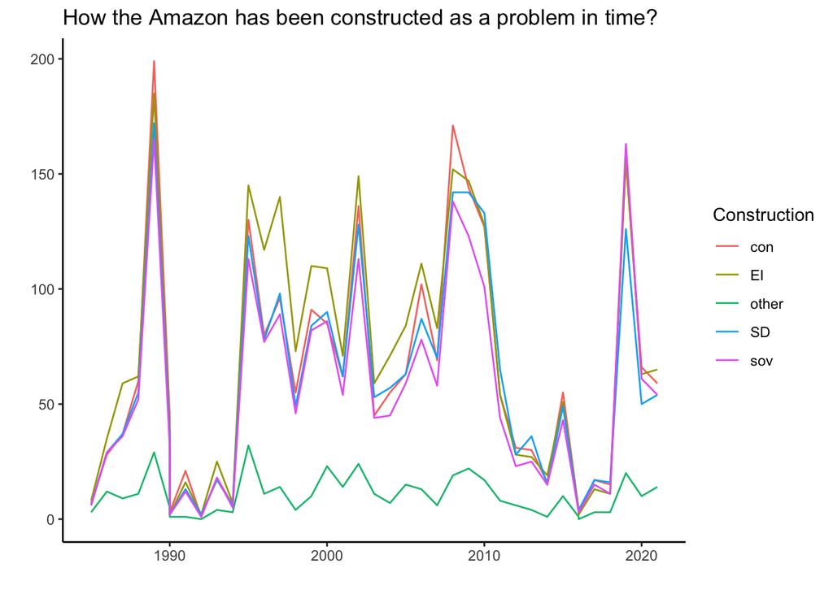

```r
library(tidyr)
library(ggplot2)
library(ggthemes)

# Get datasets
final_data_as <- readRDS("~/Documents/GitHub/amazondef/final_data_as.Rds")

# Get the data per president (Plot 1)
time_long <- final_data_as %>%
  mutate(sov = as.numeric(sov), EI = as.numeric(EI),
         SD = as.numeric(SD), con = as.numeric(con), other = as.numeric(other)) %>%
  select(-c(ID, party, title, location, date, text, AM2, false_positives, hand_coded, location_cat)) %>%
  group_by(president, year) %>%
  summarize(across(everything(), sum)) %>%
  tidyr::pivot_longer(sov:other, "Construction")
construction_time <- ggplot(time_long, aes(x = year, y = value, fill = Construction)) +
  geom_line(aes(group = Construction, color = Construction), size = 0.5) +
  labs(x = "",
       y = "",
       title = "How the Amazon has been constructed as a problem in time?") +
  theme_classic()
construction_time
```

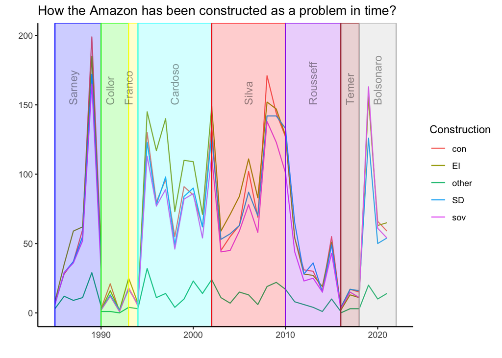

```r
# Let's try and add a labeled and colored rectangle for periods
hp = data.frame(beg = c(1985, 1990, 1993, 1994, 2002, 2010, 2016, 2018),
                end = c(1990, 1993, 1994, 2002, 2010, 2016, 2018, 2022),
                label = c(1987, 1991, 1993, 1998, 2006, 2013, 2017, 2020))
construction_time_color <- construction_time +
  annotate(geom = "rect", xmin = hp$beg, xmax = hp$end, ymin = -Inf, ymax = Inf, alpha = 0.2,
           color = c("blue", "green", "yellow", "cyan", "red", "purple", "brown", "grey"),
           fill = c("blue", "green", "yellow", "cyan", "red", "purple", "brown", "grey")) +
  annotate(geom = "text", x = hp$label, y = 150, angle = 90, alpha = 0.4, hjust = "left",
           label =  c("Sarney", "Collor", "Franco", "Cardoso", "Silva", "Rousseff", "Temer", "Bolsonaro"))
construction_time_color
```

```r
# Maybe need to change colors a bit, but idea is there!
```

Plotting Amazon construction in time, without any normalization (the first two plot), appears to indicate that the frequencies for all constructions are rather consistent for the same years. That is, the frequencies in which the Amazon is constructed as different problems in time varies for across the years and for presidents, but within the same year presidents construct the Amazon as different issues with similar frequencies. Do all presidents construct the Amazon as diverse issues in rather consistent ways within the same year? Why then do we have variation in years? Could it be that the Amazon becomes a more important theme in some years than others?

Nevertheless, we do see some interesting patterns in time. For example, for Sarney and Collor it seems that the Amazon was constructed as an issue of conservation more than other constructions. This changes with Itamar who begins to focus on the Amazon as an issue of economic integration, this is accentuated for Cardoso. During the Silva years we see a switch from constructing the Amazon overwhelmingly as an issue of economic integration, in the first mandate, to focusing on conservation when talking about the Amazon by his second term. Rousseff constructs the Amazon mostly as an issue of social development. Temer appear to not mention the Amazon much in speeches, but keeps the focus on social development issues. Finally, for Bolsonaro, the Amazon is constructed as an issue of sovereignty and conservation.

```r
# Let's create a normalizing variable
# Say we will use the number of characters for all speeches in the large dataset for that year.
BR_presid_speeches_final <- readRDS("~/Documents/GitHub/amazondef/BR_presid_speeches_final.Rds")
normalization <- BR_presid_speeches_final %>%
  select(c(text, year, president)) %>%
  mutate(char = nchar(text)) %>%
  select(-text) %>%
  group_by(year, president) %>%
  summarize(across(everything(), sum)) %>%
  mutate(char = char/10000) %>%
  arrange(year)
time_long_norm <- final_data_as %>%
  mutate(sov = as.numeric(sov), EI = as.numeric(EI),
         SD = as.numeric(SD), con = as.numeric(con), other = as.numeric(other)) %>%
  select(-c(ID, party, title, location, date, text, AM2, false_positives, hand_coded, location_cat)) %>%
  group_by(president, year) %>%
  summarize(across(everything(), sum)) %>%
  arrange(year)
```

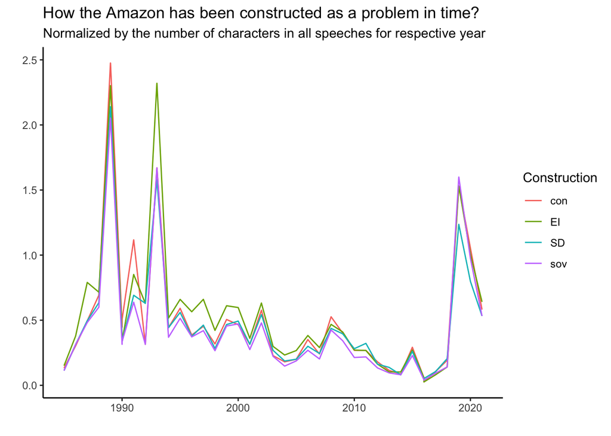

```r
time_long_norm$char <- normalization$char
time_long_norm <- time_long_norm %>%
  mutate(sov = sov/char,
         EI = EI/char,
         SD = SD/char,
         con = con/char) %>%
  select(-c(char, other)) %>%
  tidyr::pivot_longer(sov:con, "Construction")
construction_time_norm <- ggplot(time_long_norm, aes(x = year, y = value, fill = Construction)) +
  geom_line(aes(group = Construction, color = Construction), size = 0.5) +
  labs(x = "",
       y = "",
       title = "How the Amazon has been constructed as a problem in time?",
       subtitle = "Normalized by the number of characters in all speeches for respective year") +
  theme_classic()
construction_time_norm
```

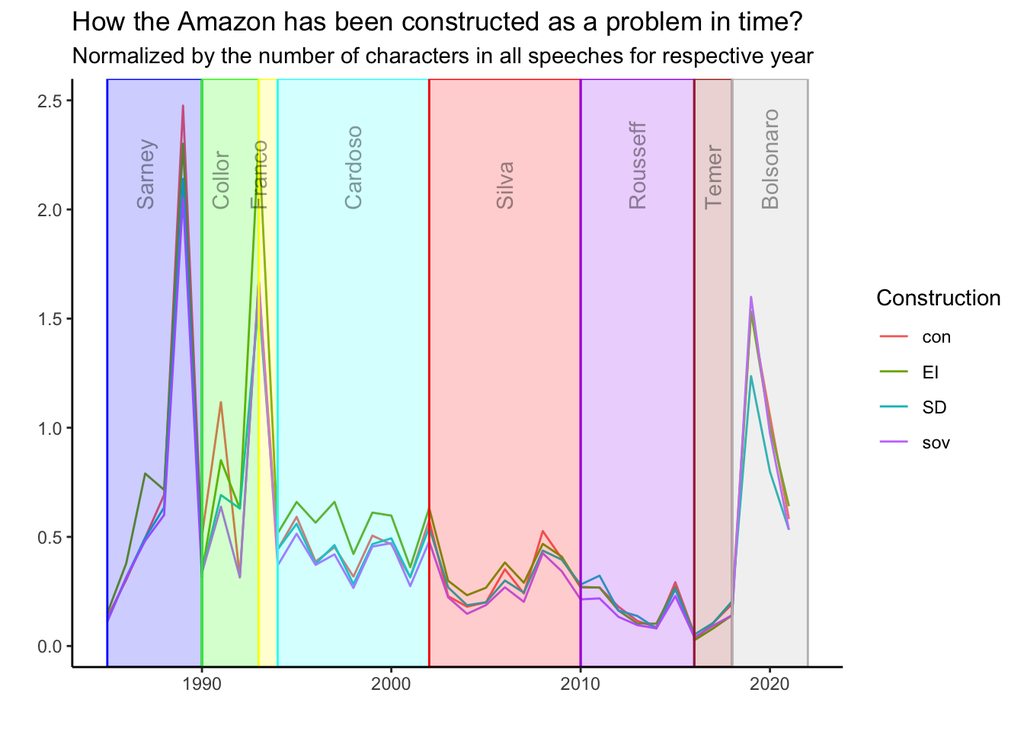

```r
# This changes things a bit!
# Let's add some colors as before
construction_time_norm_color <- construction_time_norm +
  annotate(geom = "rect", xmin = hp$beg, xmax = hp$end, ymin = -Inf, ymax = Inf, alpha = 0.2,
           color = c("blue", "green", "yellow", "cyan", "red", "purple", "brown", "grey"),
           fill = c("blue", "green", "yellow", "cyan", "red", "purple", "brown", "grey")) +
  annotate(geom = "text", x = hp$label, y = 2, angle = 90, alpha = 0.4, hjust = "left",
           label =  c("Sarney", "Collor", "Franco", "Cardoso", "Silva", "Rousseff", "Temer", "Bolsonaro"))
construction_time_norm_color
```